# Multivariate Model

### Run the model

```r
testiter = 2000
testwu = 1000
testthin = 10
testchains = 2

library(rstan)
suppressMessages({
fitTest = stan(model_code = stanmodelcode, model_name = "test",
               data = stanTest, iter = testiter, warmup=testwu, thin=testthin,
               chains = testchains, verbose = F, refresh=100)
})
```

[output not shown]

[output cut: 81 more lines]

```r
### Summarize
print(fitTest, digits_summary=3, pars=c('Intercept','beta','Tau', 'Sigma', 'scaleTau', 'scaleSigma'),
      probs = c(.025, .5, .975))
```

```
## Inference for Stan model: test.
## 2 chains, each with iter=2000; warmup=1000; thin=10;
## post-warmup draws per chain=100, total post-warmup draws=200.
##
##                 mean se_mean    sd   2.5%    50%  97.5% n_eff  Rhat
## Intercept[1]  70.151   0.036 0.421 69.311 70.118 70.912   135 1.006
## Intercept[2]  79.846   0.021 0.211 79.336 79.857 80.219   104 0.999
## Intercept[3]  89.632   0.024 0.340 88.896 89.629 90.329   200 0.992
## beta[1,1]     -1.138   0.037 0.435 -1.954 -1.136 -0.279   141 1.010
## beta[1,2]     -0.197   0.024 0.323 -0.777 -0.232  0.458   175 0.997
## beta[1,3]     -0.161   0.034 0.485 -1.131 -0.152  0.770   200 0.993
## beta[2,1]      0.478   0.037 0.448 -0.453  0.473  1.340   146 1.003
## beta[2,2]      0.454   0.022 0.289 -0.087  0.450  0.991   173 0.999
## beta[2,3]      0.910   0.033 0.473 -0.004  0.864  1.911   200 0.998
## beta[3,1]     -0.092   0.036 0.424 -0.976 -0.079  0.690   139 1.005
## beta[3,2]     -0.282   0.025 0.319 -0.937 -0.301  0.361   162 1.002
## beta[3,3]     -0.091   0.030 0.420 -0.998 -0.074  0.674   200 1.014
## beta[4,1]      0.212   0.037 0.423 -0.632  0.200  1.026   129 1.016
## beta[4,2]     -0.153   0.024 0.322 -0.748 -0.161  0.487   183 1.003
## beta[4,3]      0.062   0.057 0.493 -0.850  0.052  1.005    75 1.025
## beta[5,1]     -0.632   0.038 0.445 -1.615 -0.619  0.229   139 1.013
## beta[5,2]     -0.826   0.022 0.306 -1.444 -0.817 -0.295   197 0.992
## beta[5,3]     -0.351   0.033 0.470 -1.236 -0.378  0.535   200 0.994
## beta[6,1]      0.862   0.037 0.429  0.067  0.935  1.645   134 1.002
## beta[6,2]      0.593   0.025 0.326 -0.097  0.588  1.254   169 1.014
## beta[6,3]      1.554   0.033 0.474  0.710  1.562  2.437   200 0.996
## beta[7,1]     -2.247   0.036 0.434 -3.114 -2.220 -1.453   143 1.008
## beta[7,2]     -0.404   0.021 0.296 -0.923 -0.412  0.236   200 0.994
## beta[7,3]      0.562   0.036 0.499 -0.357  0.570  1.608   196 0.997
## beta[8,1]      0.726   0.037 0.434 -0.151  0.730  1.544   141 1.010
## beta[8,2]      0.700   0.028 0.316  0.098  0.679  1.305   129 0.992
## beta[8,3]     -0.460   0.037 0.525 -1.396 -0.447  0.529   200 0.996
## beta[9,1]     -0.111   0.037 0.437 -0.926 -0.069  0.751   142 1.004
## beta[9,2]     -0.269   0.030 0.293 -0.813 -0.269  0.352    95 0.997
## beta[9,3]     -1.034   0.036 0.479 -1.983 -0.997 -0.101   173 0.995
## beta[10,1]     1.393   0.038 0.426  0.494  1.420  2.172   129 1.005
## beta[10,2]     0.389   0.036 0.322 -0.141  0.369  1.093    79 1.006
## beta[10,3]    -0.732   0.038 0.497 -1.800 -0.711  0.242   169 1.001
## Tau[1,1]       1.000   0.000 0.000  1.000  1.000  1.000   200   NaN
## Tau[1,2]       0.414   0.019 0.273 -0.199  0.473  0.824   200 0.992
```

[output cut: 12 more lines]

```
## Sigma[2,3]    -0.001   0.004 0.049 -0.095 -0.004  0.097   162 1.000
## Sigma[3,1]    -0.014   0.003 0.043 -0.096 -0.016  0.077   200 0.998
## Sigma[3,2]    -0.001   0.004 0.049 -0.095 -0.004  0.097   162 1.000
## Sigma[3,3]     1.000   0.000 0.000  1.000  1.000  1.000   138 0.990
## scaleTau[1]    1.241   0.022 0.311  0.768  1.189  1.930   200 0.996
## scaleTau[2]    0.632   0.014 0.193  0.333  0.606  1.048   181 1.013
## scaleTau[3]    1.057   0.024 0.344  0.608  0.982  1.989   200 0.992
## scaleSigma[1]  0.945   0.002 0.027  0.889  0.944  0.997   200 1.013
## scaleSigma[2]  2.086   0.004 0.062  1.973  2.082  2.211   200 0.993
## scaleSigma[3]  2.840   0.006 0.089  2.652  2.846  2.982   200 1.009
##
## Samples were drawn using NUTS(diag_e) at Tue Oct 14 21:32:01 2014.
## For each parameter, n_eff is a crude measure of effective sample size,
## and Rhat is the potential scale reduction factor on split chains (at
## convergence, Rhat=1).
```

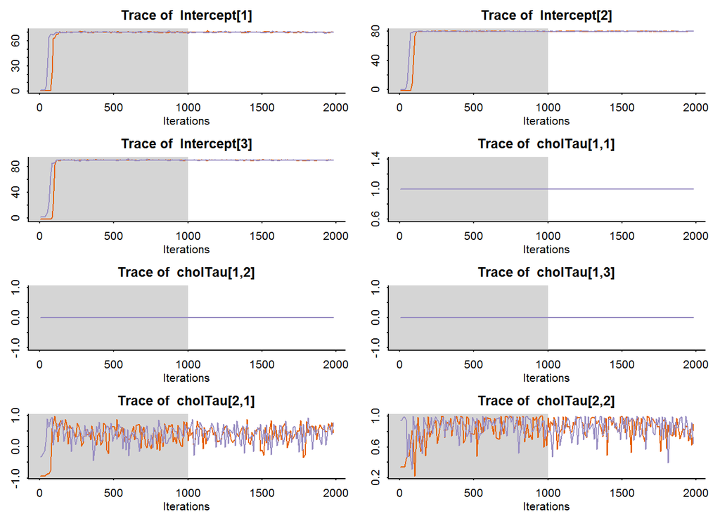

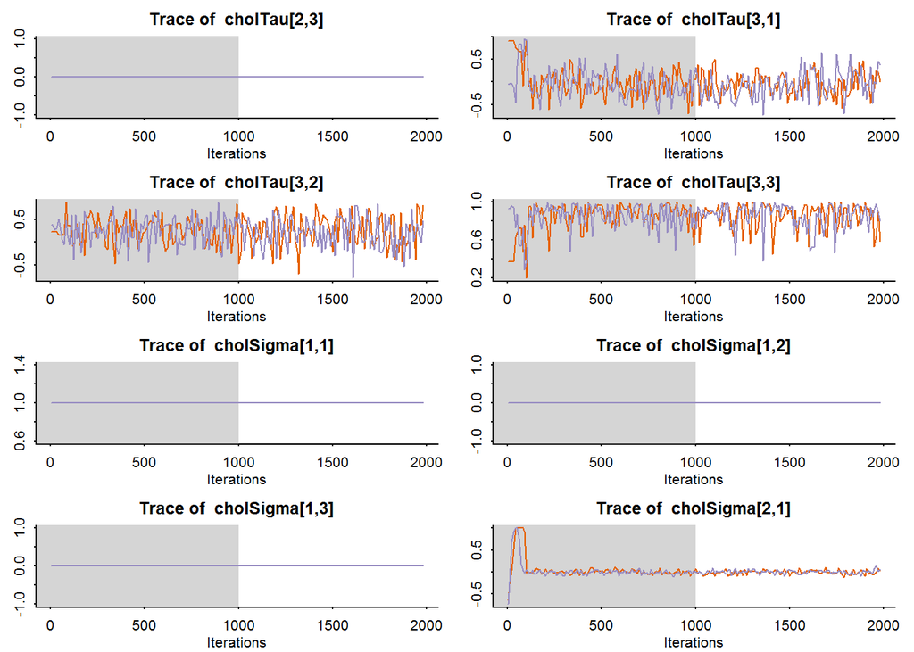

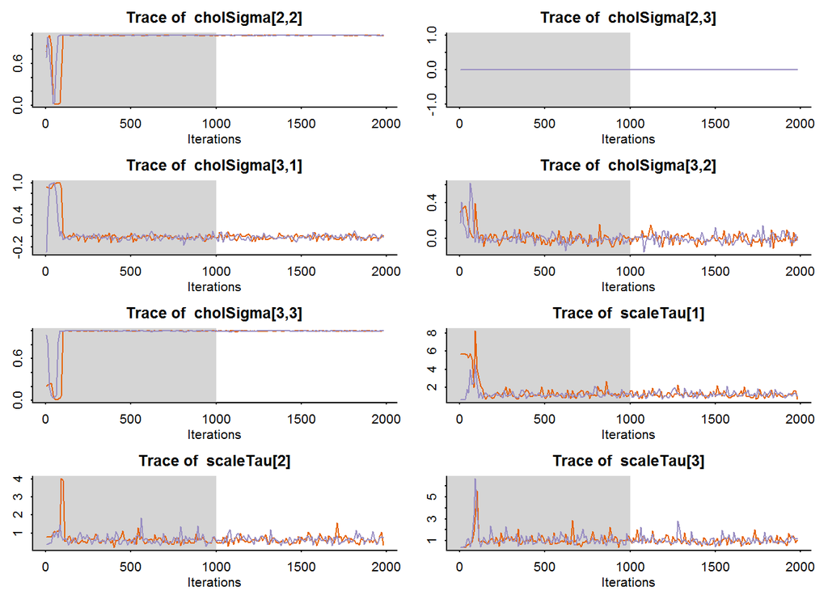

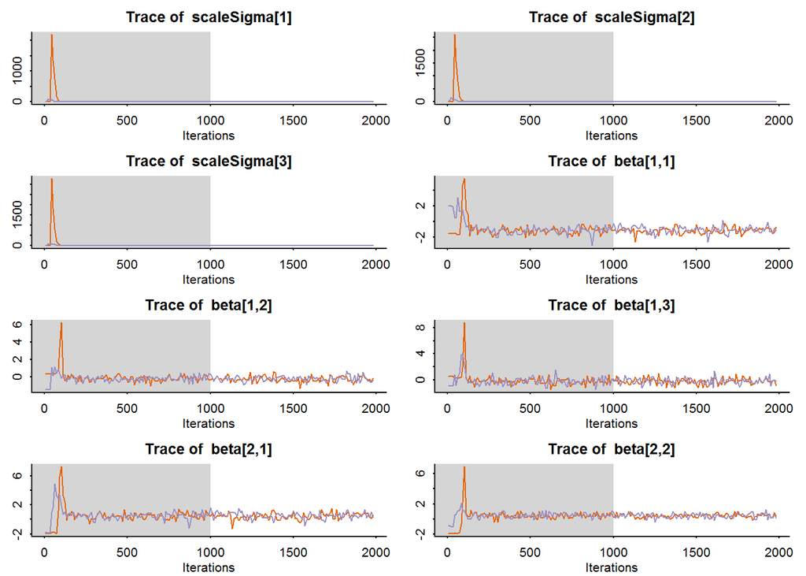

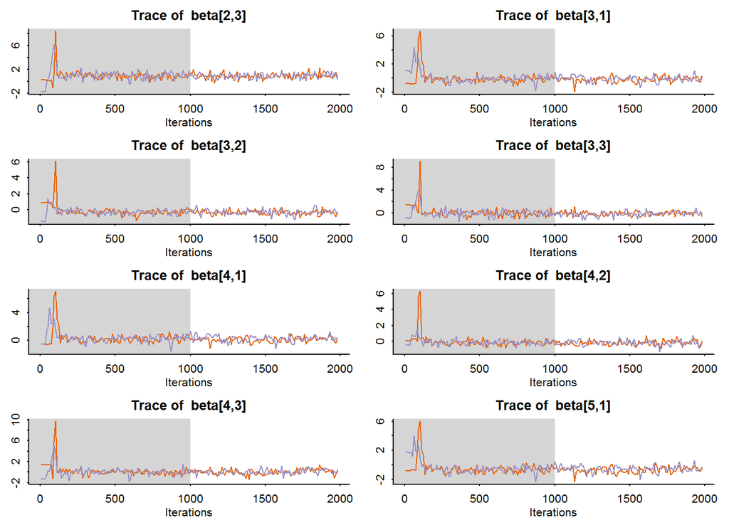

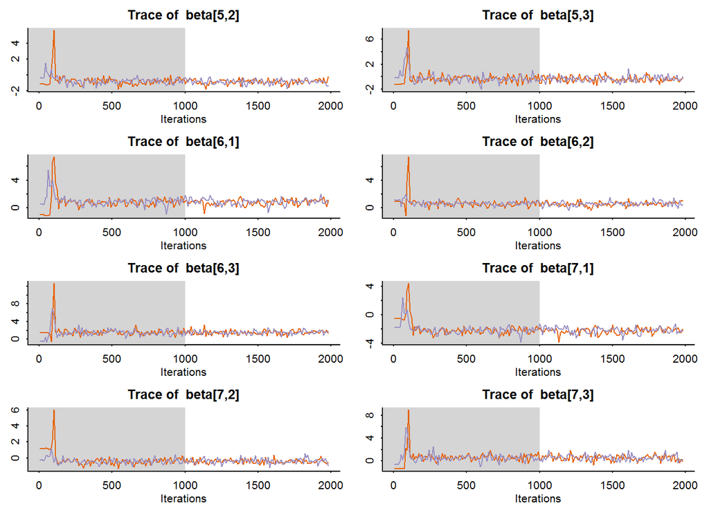

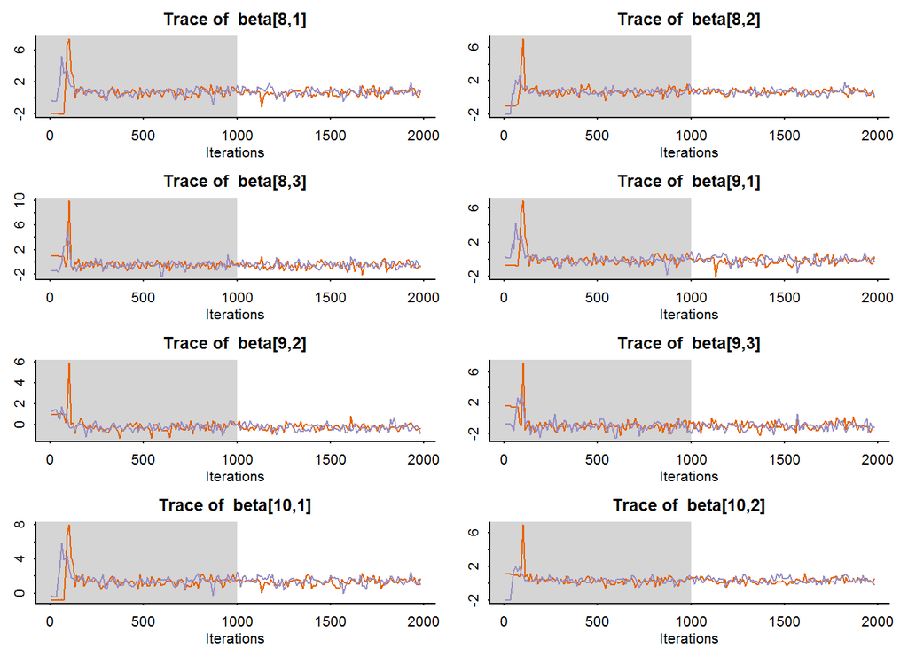

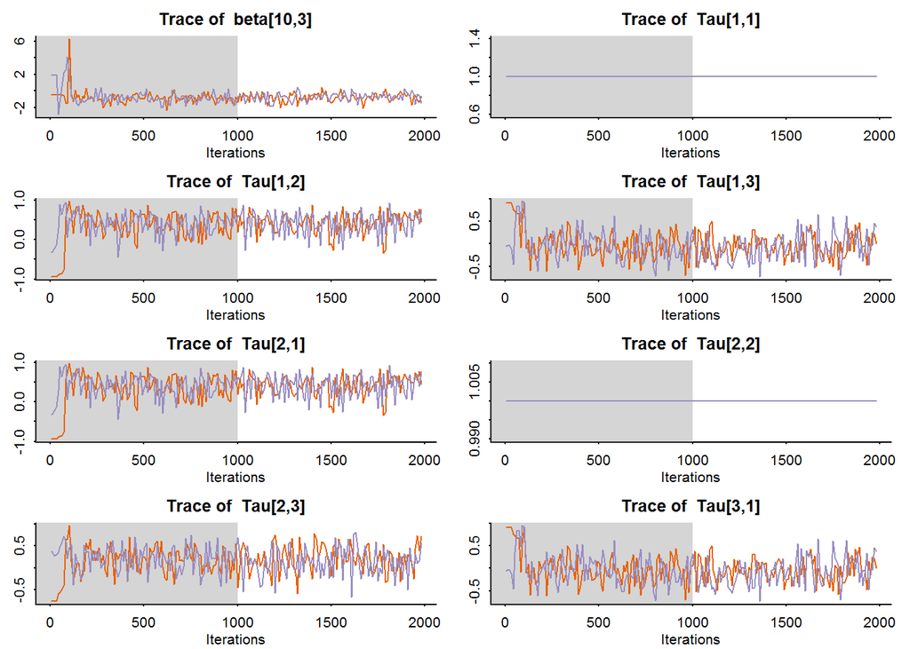

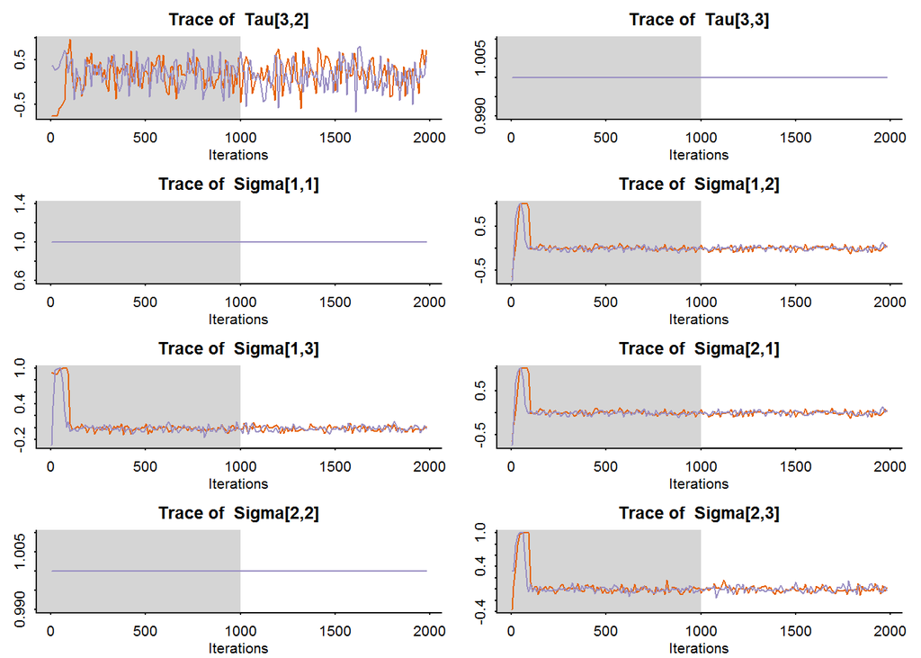

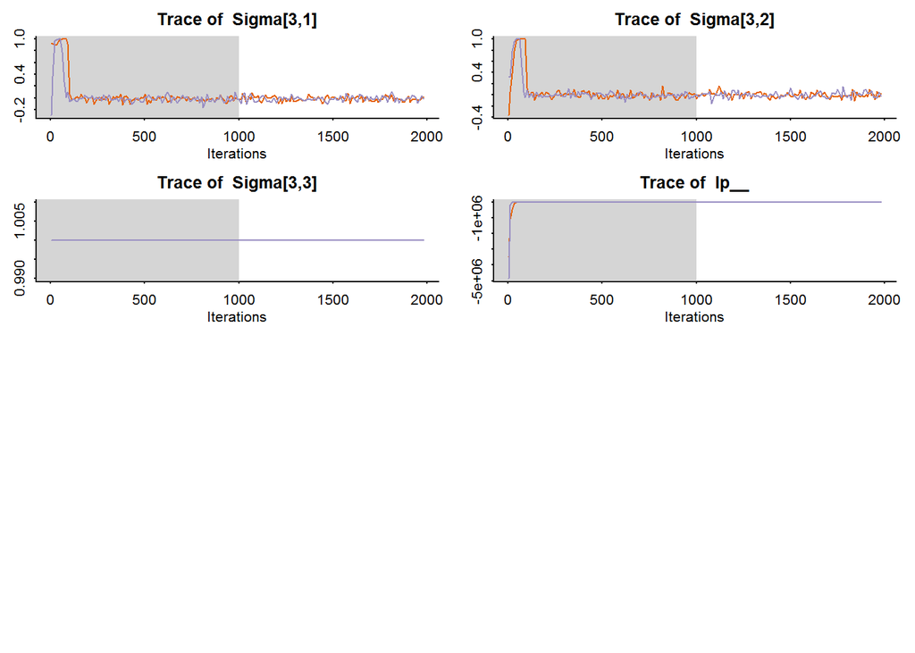

```r
# pairs(fitTest, pars=c('Intercept','mu','Tau', 'Sigma', 'scaleTau', 'scaleSigma'))
traceplot(fitTest)
```

```r
library(lme4)
lme4res = sapply(schoolWide[,c('1','2','3')], function(y) lmer(y~1|J, data=schoolWide))
sapply(lme4res, summary, simplify=F)
```

```
## $`1`
## Linear mixed model fit by REML ['lmerMod']
## Formula: y ~ 1 | J
##    Data: schoolWide
##
## REML criterion at convergence: 1398
##
## Scaled residuals:
##    Min     1Q Median     3Q    Max
## -3.240 -0.601  0.039  0.620  2.758
##
## Random effects:
##  Groups   Name        Variance Std.Dev.
##  J        (Intercept) 1.155    1.07
##  Residual             0.883    0.94
## Number of obs: 500, groups:  J, 10
##
## Fixed effects:
##             Estimate Std. Error t value
## (Intercept)   70.095      0.342     205
##
## $`2`
## Linear mixed model fit by REML ['lmerMod']
## Formula: y ~ 1 | J
##    Data: schoolWide
##
## REML criterion at convergence: 2166
##
## Scaled residuals:
##     Min      1Q  Median      3Q     Max
## -2.8211 -0.6595 -0.0064  0.6374  2.7302
##
## Random effects:
##  Groups   Name        Variance Std.Dev.
##  J        (Intercept) 0.302    0.55
##  Residual             4.315    2.08
## Number of obs: 500, groups:  J, 10
##
## Fixed effects:
##             Estimate Std. Error t value
## (Intercept)   79.843      0.197     405
##
## $`3`
## Linear mixed model fit by REML ['lmerMod']
## Formula: y ~ 1 | J
##    Data: schoolWide
##
## REML criterion at convergence: 2472
##
## Scaled residuals:
##     Min      1Q  Median      3Q     Max
## -3.0605 -0.6875  0.0014  0.6239  2.8249
##
## Random effects:
##  Groups   Name        Variance Std.Dev.
##  J        (Intercept) 0.765    0.874
##  Residual             7.934    2.817
## Number of obs: 500, groups:  J, 10
##
## Fixed effects:
##             Estimate Std. Error t value
## (Intercept)   89.684      0.304     295
```

```r
sapply(lme4res, ranef)
```

```
## $`1.J`
##    (Intercept)
## 1     -1.09335
## 2      0.52870
## 3     -0.03618
## 4      0.28172
## 5     -0.55034
## 6      0.90878
## 7     -2.20722
## 8      0.76806
## 9     -0.04452
## 10     1.44435
##
## $`2.J`
##    (Intercept)
```

[output cut: 23 more lines]

# Main model

Now we are ready for the main run, bumping up the iterations etc.

```r
###############################
### A parallelized approach ###
###############################
library(rstan)
iters = 22000
wu = 2000
thin = 20
chains = 4


library(parallel)
cl = makeCluster(chains)
clusterEvalQ(cl, library(rstan))
```

```
## [[1]]
##  [1] "rstan"     "inline"    "Rcpp"      "methods"   "stats"     "graphics"  "grDevices" "utils"     "datasets"  "base"
##
## [[2]]
##  [1] "rstan"     "inline"    "Rcpp"      "methods"   "stats"     "graphics"  "grDevices" "utils"     "datasets"  "base"
##
## [[3]]
##  [1] "rstan"     "inline"    "Rcpp"      "methods"   "stats"     "graphics"  "grDevices" "utils"     "datasets"  "base"
##
## [[4]]
##  [1] "rstan"     "inline"    "Rcpp"      "methods"   "stats"     "graphics"  "grDevices" "utils"     "datasets"  "base"
```

```r
clusterExport(cl, c('stanmodelcode', 'stanTest', 'fitTest', 'iters', 'wu', 'thin'))
p = proc.time()
parfit = parSapply(cl, 1:chains, function(i) stan(model_code = stanmodelcode, model_name = "schools",
                                             fit = fitTest, data = stanTest, iter = iters,
                                             warmup=wu, thin=thin, chains = 1, chain_id=i,
                                             verbose = T, refresh=4000),
                   simplify=F)
proc.time() - p
```

```
##    user  system elapsed
##    1.12    0.01 1412.58
```

```r
stopCluster(cl)

# combine the chains
fitMain = sflist2stanfit(parfit)




print(fitMain, pars= c('Intercept','beta','Tau', 'Sigma', 'scaleTau', 'scaleSigma'), digits=3,
      probs = c(.025, .5, 0.975))
```

```
## Inference for Stan model: test.
## 4 chains, each with iter=22000; warmup=2000; thin=20;
## post-warmup draws per chain=1000, total post-warmup draws=4000.
##
##                 mean se_mean    sd   2.5%    50%  97.5% n_eff  Rhat
## Intercept[1]  70.112   0.007 0.413 69.311 70.113 70.959  3550 0.999
## Intercept[2]  79.845   0.004 0.229 79.392 79.844 80.293  3787 1.000
## Intercept[3]  89.666   0.006 0.380 88.906 89.670 90.412  3769 1.000
## beta[1,1]     -1.106   0.007 0.430 -1.985 -1.100 -0.263  3522 1.000
## beta[1,2]     -0.204   0.005 0.323 -0.837 -0.207  0.442  3996 1.000
## beta[1,3]     -0.132   0.008 0.503 -1.132 -0.127  0.861  3665 1.000
## beta[2,1]      0.513   0.007 0.430 -0.356  0.512  1.341  3505 0.999
## beta[2,2]      0.432   0.005 0.319 -0.183  0.425  1.072  3900 1.000
## beta[2,3]      0.914   0.008 0.511 -0.030  0.901  1.991  3981 0.999
## beta[3,1]     -0.061   0.007 0.430 -0.926 -0.060  0.781  3565 0.999
## beta[3,2]     -0.281   0.005 0.317 -0.942 -0.264  0.293  4000 1.000
## beta[3,3]     -0.084   0.008 0.502 -1.078 -0.093  0.902  3719 1.000
## beta[4,1]      0.261   0.007 0.428 -0.593  0.266  1.097  3499 0.999
## beta[4,2]     -0.119   0.005 0.318 -0.771 -0.110  0.501  3772 1.001
## beta[4,3]      0.022   0.008 0.499 -0.973  0.022  1.004  3850 1.000
## beta[5,1]     -0.582   0.007 0.425 -1.443 -0.578  0.232  3570 1.000
## beta[5,2]     -0.806   0.005 0.341 -1.520 -0.789 -0.196  4000 1.000
## beta[5,3]     -0.359   0.008 0.505 -1.376 -0.351  0.607  4000 1.001
## beta[6,1]      0.894   0.007 0.429  0.037  0.894  1.766  3627 0.999
## beta[6,2]      0.605   0.005 0.326 -0.012  0.589  1.265  4000 1.000
## beta[6,3]      1.537   0.008 0.538  0.548  1.516  2.653  4000 0.999
## beta[7,1]     -2.217   0.007 0.432 -3.097 -2.214 -1.374  3736 0.999
## beta[7,2]     -0.453   0.005 0.329 -1.101 -0.448  0.189  3897 1.000
## beta[7,3]      0.593   0.008 0.503 -0.381  0.586  1.644  3794 1.000
## beta[8,1]      0.769   0.007 0.426 -0.080  0.773  1.586  3547 0.999
## beta[8,2]      0.698   0.005 0.336  0.086  0.683  1.412  3805 1.000
## beta[8,3]     -0.480   0.008 0.512 -1.506 -0.468  0.508  3901 0.999
## beta[9,1]     -0.062   0.007 0.432 -0.956 -0.055  0.789  3582 1.000
## beta[9,2]     -0.267   0.005 0.321 -0.897 -0.263  0.349  4000 0.999
## beta[9,3]     -1.076   0.008 0.504 -2.136 -1.061 -0.138  4000 0.999
## beta[10,1]     1.429   0.007 0.429  0.555  1.425  2.275  3623 0.999
## beta[10,2]     0.379   0.005 0.325 -0.245  0.375  1.026  3743 1.001
## beta[10,3]    -0.808   0.008 0.515 -1.858 -0.805  0.187  3851 1.000
## Tau[1,1]       1.000   0.000 0.000  1.000  1.000  1.000  4000   NaN
## Tau[1,2]       0.463   0.004 0.256 -0.119  0.496  0.868  3786 1.000
```

[output cut: 12 more lines]

```
## Sigma[2,3]    -0.001   0.001 0.045 -0.092  0.000  0.086  3742 0.999
## Sigma[3,1]    -0.015   0.001 0.045 -0.100 -0.015  0.073  3831 1.000
## Sigma[3,2]    -0.001   0.001 0.045 -0.092  0.000  0.086  3742 0.999
## Sigma[3,3]     1.000   0.000 0.000  1.000  1.000  1.000  4000 0.999
## scaleTau[1]    1.221   0.005 0.318  0.757  1.170  1.982  4000 1.001
## scaleTau[2]    0.634   0.003 0.213  0.320  0.602  1.160  4000 1.001
## scaleTau[3]    1.068   0.006 0.362  0.557  1.011  1.938  4000 0.999
## scaleSigma[1]  0.944   0.000 0.030  0.887  0.944  1.005  4000 1.000
## scaleSigma[2]  2.085   0.001 0.065  1.962  2.083  2.221  4000 1.000
## scaleSigma[3]  2.829   0.001 0.090  2.661  2.826  3.014  3681 1.000
##
## Samples were drawn using NUTS(diag_e) at Tue Oct 14 21:55:37 2014.
## For each parameter, n_eff is a crude measure of effective sample size,
## and Rhat is the potential scale reduction factor on split chains (at
## convergence, Rhat=1).
```

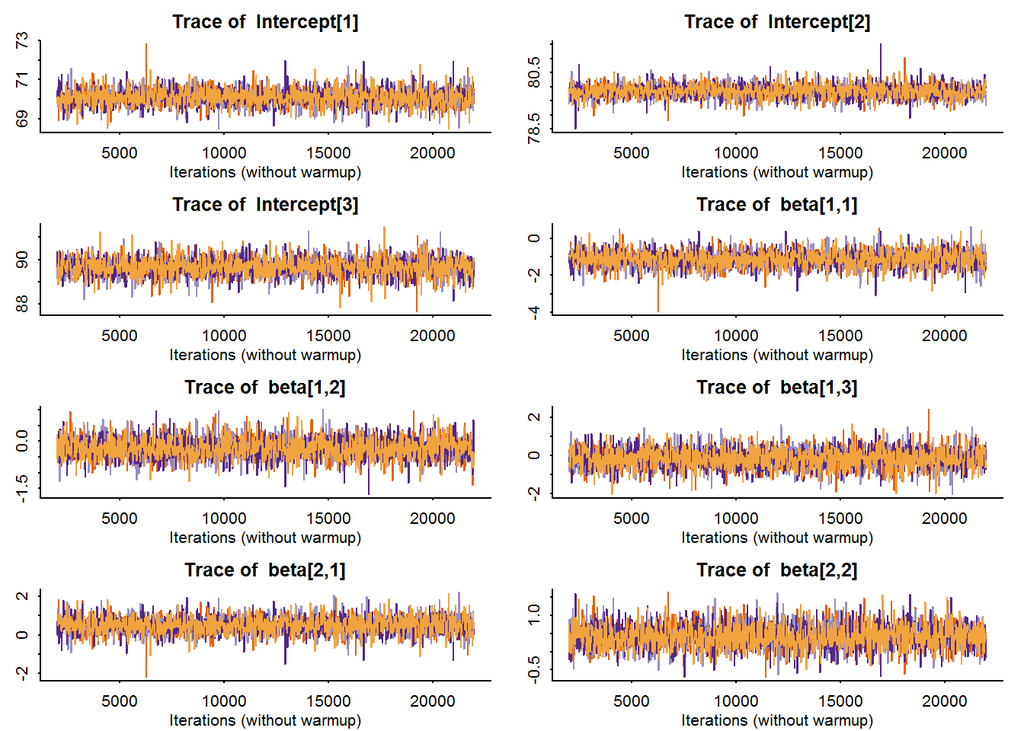

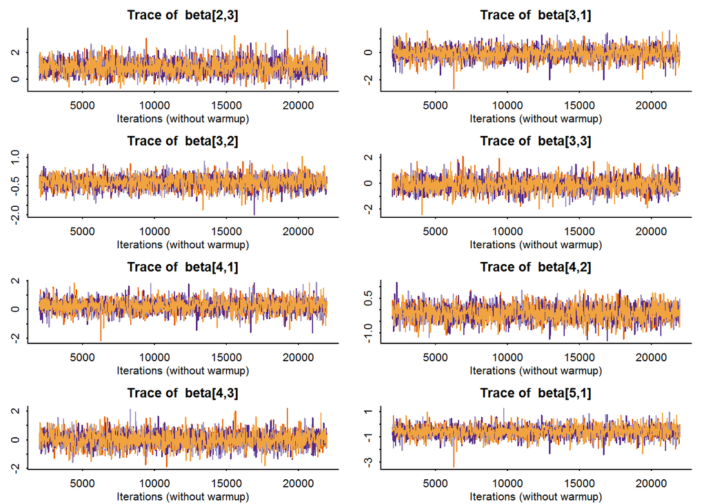

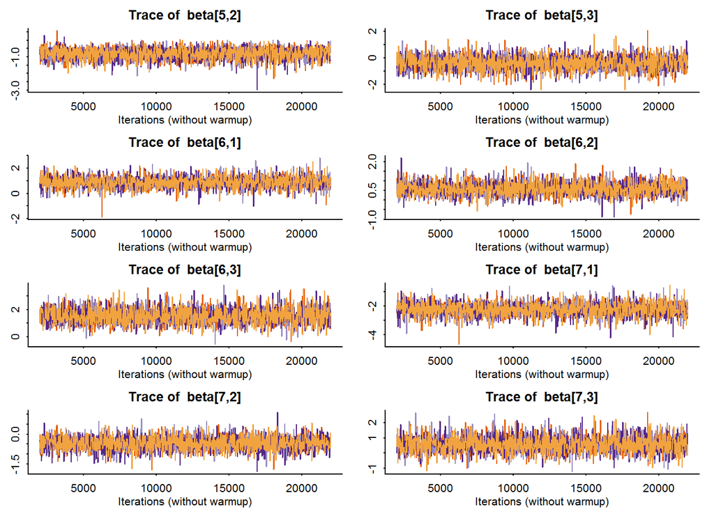

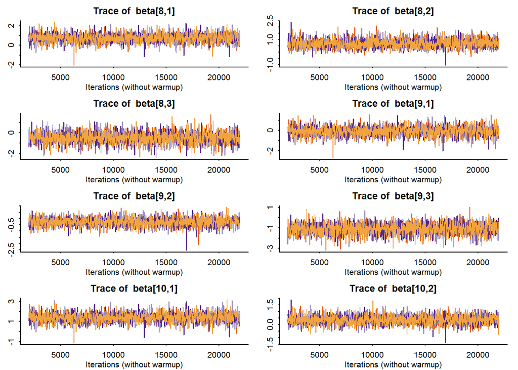

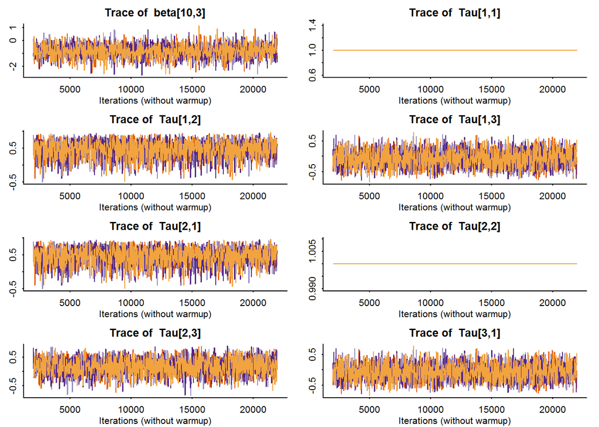

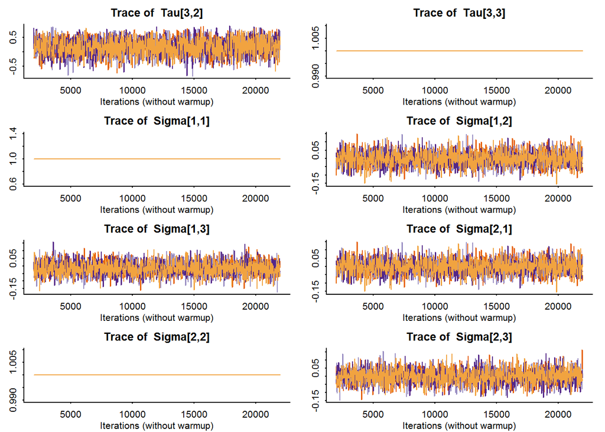

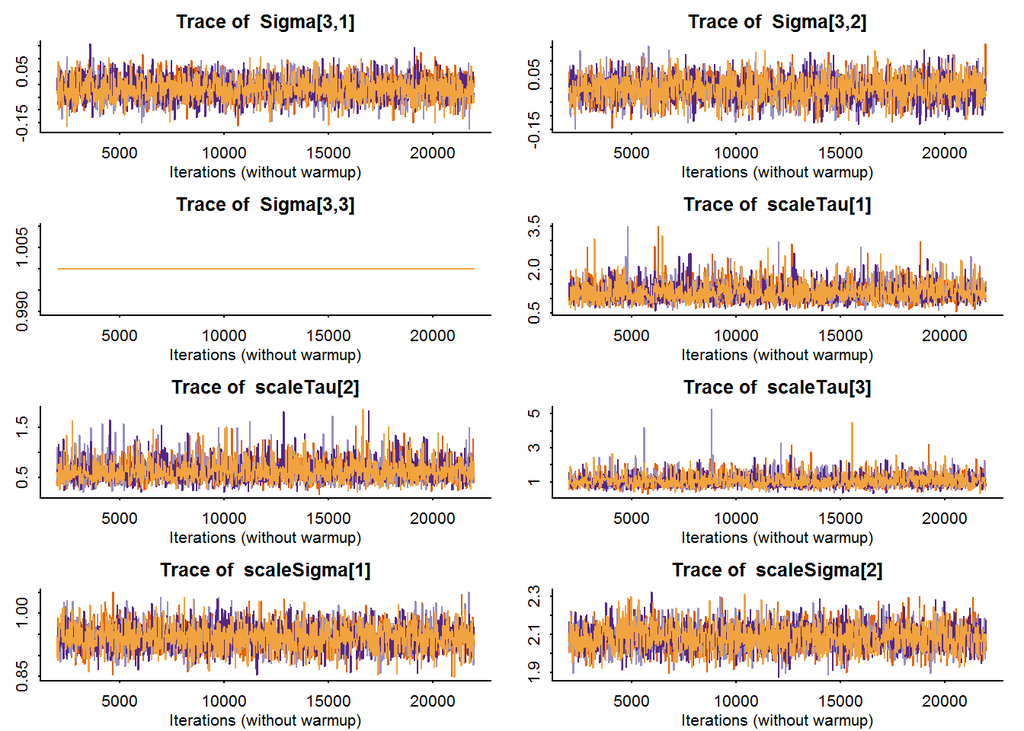

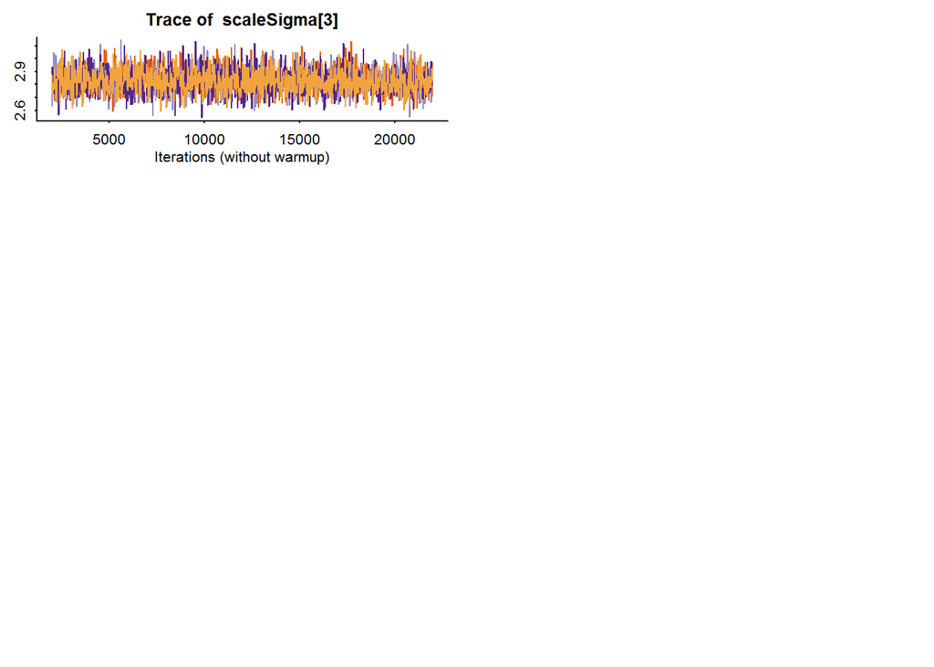

```r
# examine some diagnostics
traceplot(fitMain, inc_warmup=F, pars=c('Intercept','beta','Tau', 'Sigma', 'scaleTau', 'scaleSigma'))
```

```r
ainfo = get_adaptation_info(fitMain)
cat(ainfo[[1]])
```

```
## # Adaptation terminated
## # Step size = 0.104022
## # Diagonal elements of inverse mass matrix:
## # 0.145244, 0.0492298, 0.138217, 0.12971, 0.0900368, 0.156911, 0.00182789, 0.00243278, 0.00221716, 0.0629269, 0.10714, 0.099429, 0.0010533, 0.000913419, 0.00113173, 0.163393, 0.162354, 0.161332, 0.153032, 0.157956, 0.160559, 0.161751, 0.159106, 0.16104, 0.151349, 0.106022, 0.10149, 0.0963951, 0.1…
```

```r
samplerpar = get_sampler_params(fitMain)[[1]]
summary(samplerpar)
```

```
##  accept_stat__     stepsize__       treedepth__     n_leapfrog__    n_divergent__
##  Min.   :0.000   Min.   :0.00012   Min.   : 1.00   Min.   :   1.0   Min.   :0.0000
##  1st Qu.:0.897   1st Qu.:0.10402   1st Qu.: 5.00   1st Qu.:  31.0   1st Qu.:0.0000
##  Median :0.962   Median :0.10402   Median : 5.00   Median :  31.0   Median :0.0000
##  Mean   :0.918   Mean   :0.10498   Mean   : 5.03   Mean   :  34.6   Mean   :0.0018
##  3rd Qu.:0.990   3rd Qu.:0.10402   3rd Qu.: 5.00   3rd Qu.:  31.0   3rd Qu.:0.0000
##  Max.   :1.000   Max.   :0.24253   Max.   :11.00   Max.   :2047.0   Max.   :1.0000
```

# Use coda for additional inspection

## Density and Trace

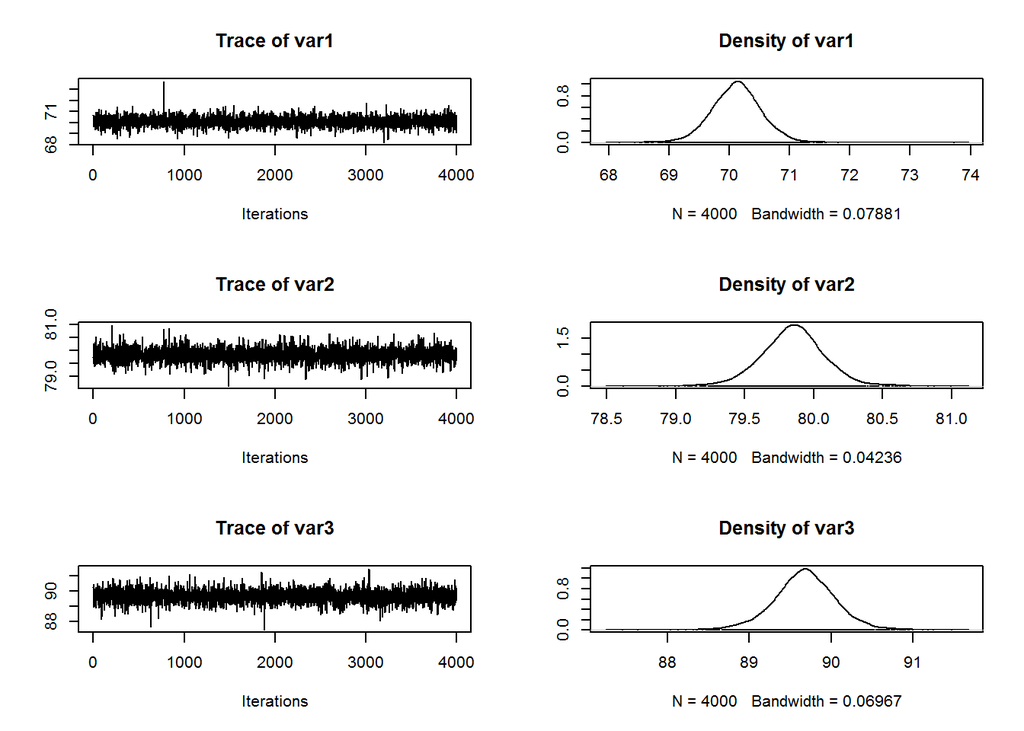

```r
library(coda)
Int = as.mcmc(extract(fitMain, par='Intercept')$Intercept)
plot(Int)
```

```r
betas = extract(fitMain, par='beta')$beta # array
str(betas)
```

```
##  num [1:4000, 1:10, 1:3] -1.761 -0.641 -1.015 -0.844 -0.81 ...
##  - attr(*, "dimnames")=List of 3
##   ..$ iterations: NULL
##   ..$           : NULL
##   ..$           : NULL
```

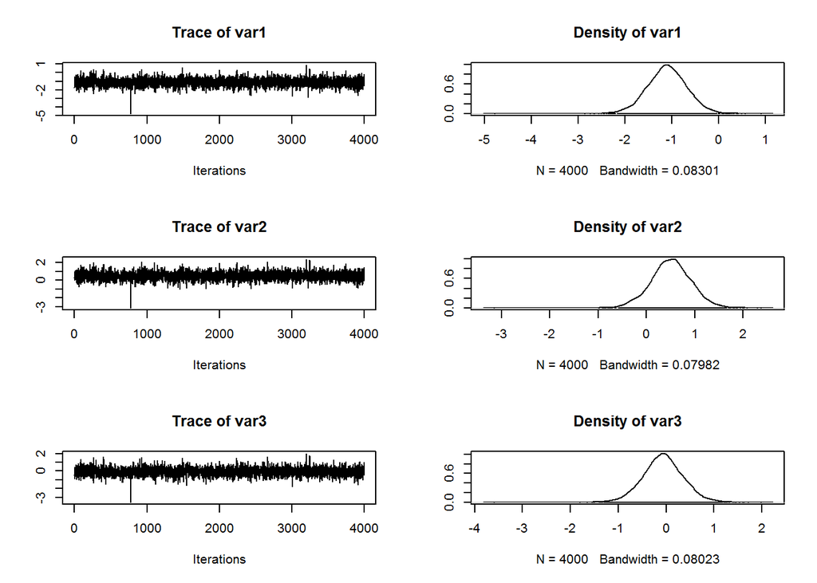

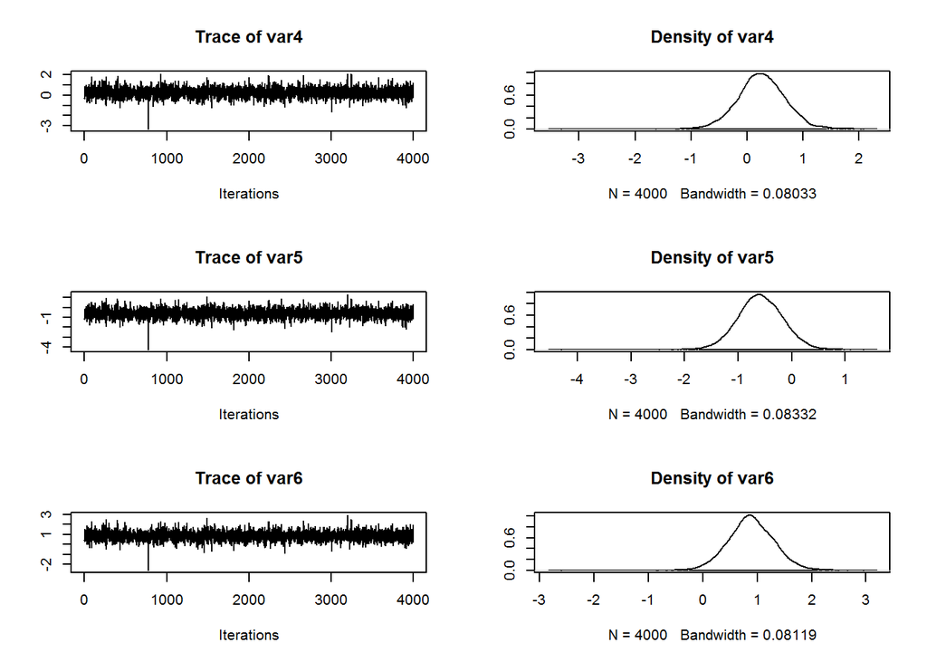

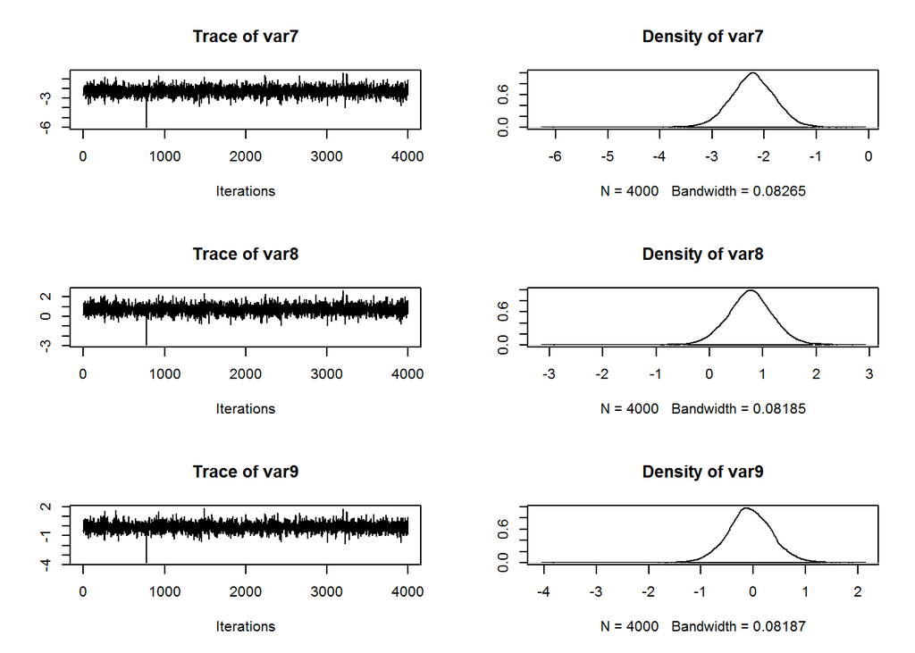

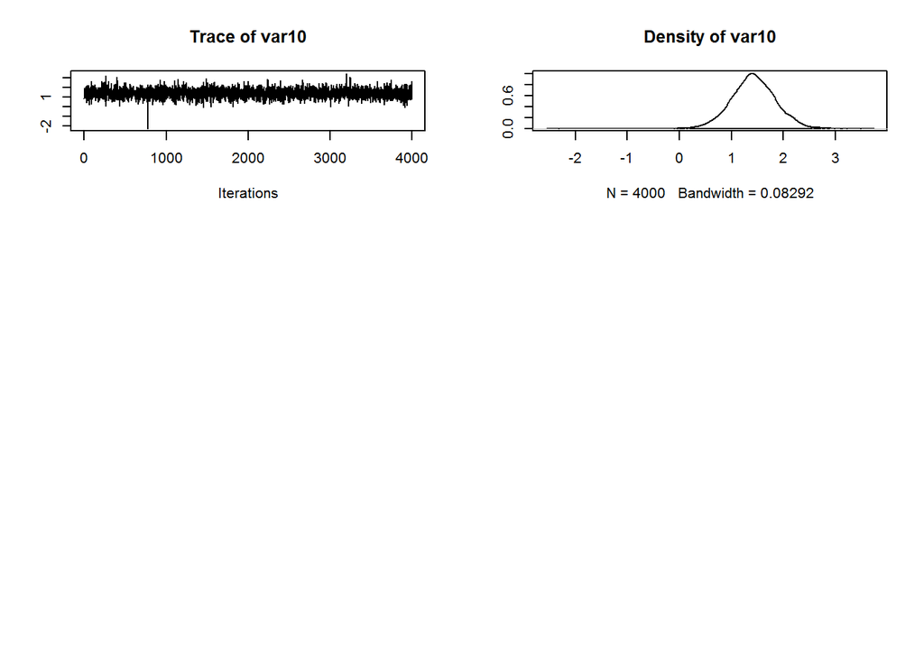

```r
plot(as.mcmc(betas[,,1]))
```

## Autocorrelation

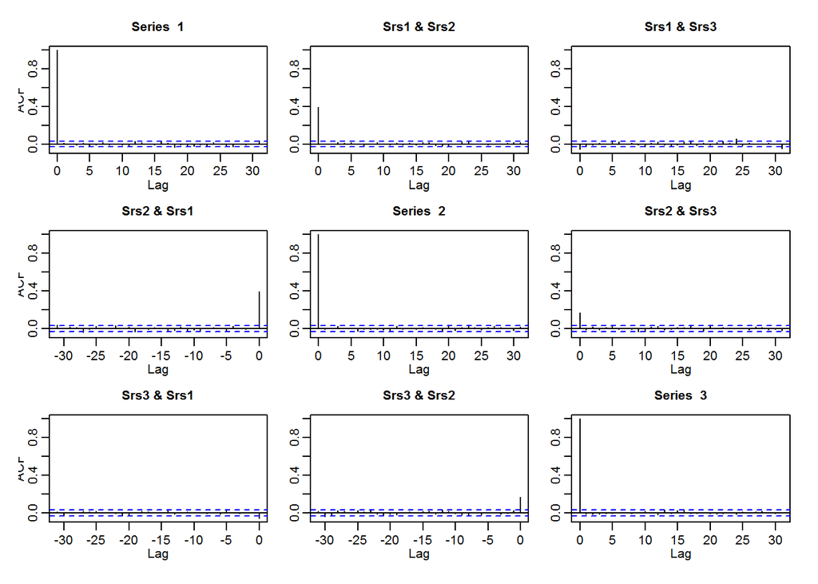

```r
acf(Int)
```

# Inspect induced Tau correlation

One might notice that even though the Tau matrix was diagonal, correlations were estimated that were not zero. This is spurious due to the fact that we had only 10 classrooms.

```r
R.utils::sourceDirectory('Code/Functions')
library(lme4)
ranefs = sapply(schoolWide[,c('1','2','3')], function(y) ranef(lmer(y~1|J, data=schoolWide))$J$'(Intercept)')
cor(ranefs) # spurious?
```

```
##          1      2        3
## 1  1.00000 0.6530 -0.07093
## 2  0.65300 1.0000  0.25188
## 3 -0.07093 0.2519  1.00000
```

```r
STest = 3
nTest = 50
JTest = 500
TauTest = matrix(c(1, 0, 0,
                   0, 1, 0,
                   0, 0, 1), nrow = 3, byrow = TRUE)

SigmaTest = matrix(c(1, 0, 0,
                     0, 2^2, 0,
                     0, 0, 3^2), nrow = 3, byrow = TRUE)

MuTest = c(70, 80, 90)

schooldatTest = dataGenHMLM2(S=STest, n=nTest, J=JTest, mu=MuTest,
                             Tau = TauTest,
                             Sigma =  SigmaTest)
str(schooldatTest)
```

```
## 'data.frame':    75000 obs. of  12 variables:
##  $ S     : int  1 2 3 1 2 3 1 2 3 1 ...
##  $ n     : int  1 1 1 2 2 2 3 3 3 4 ...
##  $ J     : int  1 1 1 1 1 1 1 1 1 1 ...
##  $ idL2  : int  1 1 1 2 2 2 3 3 3 4 ...
##  $ idL3  : int  1 1 1 1 1 1 1 1 1 1 ...
##  $ mu    : num  70 80 90 70 80 90 70 80 90 70 ...
##  $ e     : num  -0.3033 -0.336 0.0716 -1.0191 -2.5394 ...
##  $ y     : num  70.2 78.6 89.8 69.5 76.4 ...
##  $ beta_j: num  70.5 78.9 89.7 70.5 78.9 ...
##  $ ind1  : num  1 0 0 1 0 0 1 0 0 1 ...
##  $ ind2  : num  0 1 0 0 1 0 0 1 0 0 ...
##  $ ind3  : num  0 0 1 0 0 1 0 0 1 0 ...
##  - attr(*, "out.attrs")=List of 2
##   ..$ dim     : int  3 50 500
##   ..$ dimnames:List of 3
##   .. ..$ Var1: chr  "Var1=1" "Var1=2" "Var1=3"
##   .. ..$ Var2: chr  "Var2= 1" "Var2= 2" "Var2= 3" "Var2= 4" ...
##   .. ..$ Var3: chr  "Var3=  1" "Var3=  2" "Var3=  3" "Var3=  4" ...
```

```r
library(reshape2)
schoolSlimTest = schooldatTest[,c('S','n','J', 'y')]
schoolWideTest = dcast(schoolSlimTest, J+n~S)
ranefs = sapply(schoolWideTest[,c('1','2','3')],
                function(y) ranef(lmer(y~1|J, data=schoolWideTest))$J$'(Intercept)')
cor(ranefs)
```

```
##          1       2        3
## 1 1.000000 0.02539 0.005199
## 2 0.025387 1.00000 0.060982
## 3 0.005199 0.06098 1.000000
```

## Automate over J sizes

We’ll write a function to look at the Tau correlation matrix over different classroom sizes $J$. With very low J, the correlation might catch your eye, but even then the 95% credible intervals would include zero (see above). With larger $J$ we get the expected bouncing around zero.

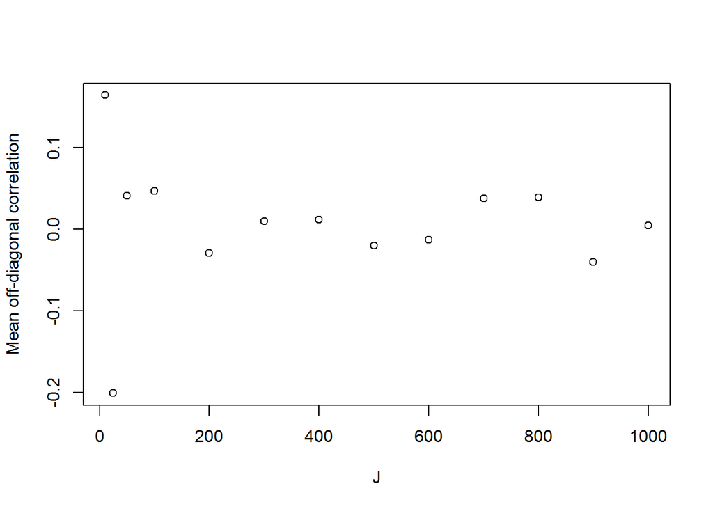

```r
examineCor = function(J){
  R.utils::sourceDirectory('Code/Functions')
  # J is vector of J sizes
  STest = 3
  nTest = 50
  JTest = 500
  TauTest = matrix(c(1, 0, 0,
                     0, 1, 0,
                     0, 0, 1), nrow = 3, byrow = TRUE)

  SigmaTest = matrix(c(1, 0, 0,
                       0, 2^2, 0,
                       0, 0, 3^2), nrow = 3, byrow = TRUE)

  MuTest = c(70, 80, 90)

  schooldatList = sapply(J, function(j) dataGenHMLM2(S=STest, n=nTest, J=j, mu=MuTest,
                                                     Tau = TauTest, Sigma =  SigmaTest),
                         simplify=F)

  require(reshape2)
  schoolSlimList = lapply(schooldatList, function(data) data[,c('S','n','J', 'y')])
  schoolWideList = suppressMessages({ lapply(schoolSlimList, function(data) dcast(data, J+n~S)) })

  require(lme4)
  ranefList = lapply(schoolWideList, function(data)
    sapply(data[,c('1','2','3')], function(y) ranef(lmer(y~1|J, data=data))$J$'(Intercept)')
    )


  corList = lapply(ranefList, cor)
  meancor = sapply(corList, function(cormat) mean(cormat[lower.tri(cormat)]))

  out = list(corList, meancor)
  out
}

# debugonce(examineCor)
J = c(10, 25, 50, seq(100, 1000, 100))
test = examineCor(J)
plot(J, test[[2]], ylab='Mean off-diagonal correlation')
```

# Save Object/Image

```r
# save.image()
```

# End of file information

```r
### Subsequent files that rely on this one if any
# X.R
# Y.R
```